# Latent Profile Analysis

Labs created by Adam Garber and Dina Arch

Updated: November 15, 2024

`University of California, Santa Barbara`

Load packages

```r
library(naniar)
library(tidyverse)
library(haven)
library(glue)
library(MplusAutomation)
library(here)
library(janitor)
library(gt)
library(tidyLPA)
library(pisaUSA15)
library(cowplot)
library(filesstrings)
library(patchwork)
library(RcppAlgos)
here::i_am("lpa.Rmd")

# Install dataset devtools::install_github('jrosen48/pisaUSA15')
# library(pisaUSA15)
```

*Example: PISA Student Data*

Variables:

**`broad_interest`**

composite measure of students’ self reported broad interest

**`enjoyment`**

composite measure of students’ self reported enjoyment

**`instrumental_mot`**

composite measure of students’ self reported instrumental motivation

**`self_efficacy`**

composite measure of students’ self reported self efficacy

## Latent Profile Models

Latent Profile Analysis (LPA) is a statistical modeling approach for estimating distinct profiles of variables. In the social sciences and in educational research, these profiles could represent, for example, how different youth experience dimensions of being engaged (i.e., cognitively, behaviorally, and affectively) at the same time. Note that LPA works best with continuous variables (and, in some cases, ordinal variables), but is not appropriate for dichotomous (binary) variables.

Many analysts have carried out LPA using a latent variable modeling approach. From this approach, different parameters - means, variances, and covariances - are freely estimated across profiles, fixed to be the same across profiles, or constrained to be zero. The MPlus software is commonly used to estimate these models (see [here](https://www.statmodel.com/examples/mixture.shtml)) using the expectation-maximization (EM) algorithm to obtain the maximum likelihood estimates for the parameters.

Different *models* (or how or whether parameters are estimated) can be specified and estimated. While MPlus is widely-used (and powerful), it is costly, closed-source, and can be difficult to use, particularly with respect to interpreting or using the output of specified models as part of a reproducible workflow

## Terminology for specifying variance-covariance matrix

The code used to estimate LPA models in this walkthrough is from the `tidyLPA` package. `TidyLPA`([source](https://data-edu.github.io/tidyLPA/articles/Introduction_to_tidyLPA.html)) is an R package designed to estimate latent profile models using a tidy framework. It can interface with Mplus via the MplusAutomation package, enabling the estimation of latent profile models with different variance-covariance structures.

- `model 1` Profile-invariant / Diagonal: Equal variances, and covariances fixed to 0
- `model 2` Profile-varying / Diagonal: Free variances and covariances fixed to 0
- `model 3` Profile-invariant / Non-Diagonal: Equal variances and equal covariances
  - Note: an alternative to Model 3 is freely estimating the covariances
- `model 4` Free variances, and equal covariances
- `model 5` Equal variances, and free covariances
- `model 6` Profile Varying / Non-Diagonal: Free variances and free covariances

### Model 1

*Profile-invariant/diagonal:*

- *Equal Variances*: Variances are fixed to equality across the profiles (i.e., variances are constrained to be equal for each profile).
- *Covariances fixed to zero* (i.e., the off-diagonal cells of the matrix are zero).

The most parsimonious model and the most restricted.

$$\begin{pmatrix}
\sigma^2_1 & 0 & 0 \\
0 & \sigma^2_2 & 0 \\
0 & 0 & \sigma^2_3 \\
\end{pmatrix}$$

### Model 2

*Profile-varying/diagonal:*

- *Free variances*: Variances parameters are freely estimated across the profiles (i.e., variances vary by profile).
- *Covariances* *fixed to zero* (i.e., the off-diagonal cells of the matrix are zero).

This model is more flexible and less parsimonious than model 1.

$$\begin{pmatrix}
\sigma^2_{1p} & 0 & 0 \\
0 & \sigma^2_{2p} & 0 \\
0 & 0 & \sigma^2_{3p} \\
\end{pmatrix}$$

### Model 3

*Profile-invariant/ non-diagonal or unrestricted:*

- *Equal variances:* Variances are fixed to equality across profile. (i.e., variances are constrained to be same for each profile).
- *Equal Covariances*: The covariances are now estimated and constrained to be equal.
  - An alternative to Model 3 is freely estimating the covariances (Model 5 here).

$$\begin{pmatrix}
\sigma^2_1 & \sigma_{12} & \sigma_{13} \\
\sigma_{12} & \sigma^2_2 & \sigma_{23} \\
\sigma_{13} & \sigma_{23} & \sigma^2_3 \\
\end{pmatrix}$$

### Model 4

Varying means, varying variances, and equal covariances:

- *Free variances*: Variances parameters are freely estimated across profiles (i.e., variances vary by profile).
- *Equal Covariances*: Covariances are constrained to be equal.

This model is also considered to be an extension of Model 3.

$$\begin{pmatrix}
\sigma^2_{1p} & \sigma_{12} & \sigma_{13} \\
\sigma_{12} & \sigma^2_{2p} & \sigma_{23} \\
\sigma_{13} & \sigma_{23} & \sigma^2_{3p} \\
\end{pmatrix}$$

### Model 5

Varying means, equal variances, and varying covariances:

- *Equal variances:* Variances are fixed to equality across the profiles. (i.e., variances are constrained to be same for each profile).
- *Free Covariances*: Covariances are now freely estimated across the profiles.

This model is also considered to be an extension of Model 3.

$$\begin{pmatrix}
\sigma^2_{1} & \sigma_{12p} & \sigma_{13p} \\
\sigma_{12p} & \sigma^2_{2} & \sigma_{23p} \\
\sigma_{13p} & \sigma_{23p} & \sigma^2_{3} \\
\end{pmatrix}$$

### Model 6

*Profile-varying / Non-diagonal*:

- *Free variances*: Variances parameters are freely estimated across profiles (i.e., variances vary by profile).
- *Free Covariances*: Covariances are now freely estimated across the profiles.

This is the most complex and unrestricted model. It is also the least parsimonious

*Note*: The unrestricted model is also sometimes known as Model 4.

$$\begin{pmatrix}
\sigma^2_{1p} & \sigma_{12p} & \sigma_{13p} \\
\sigma_{12p} & \sigma^2_{2p} & \sigma_{23p} \\
\sigma_{13p} & \sigma_{23p} & \sigma^2_{3p} \\
\end{pmatrix}$$

## Prepare Data

```r
pisa <- pisaUSA15[1:500, ] %>%
    dplyr::select(broad_interest, enjoyment, instrumental_mot, self_efficacy)
```

## Descriptive Statistics

Quick Summary

```r
summary(pisa)
```

```
##  broad_interest    enjoyment    instrumental_mot self_efficacy
##  Min.   :1.000   Min.   :1.00   Min.   :1.000    Min.   :1.000
##  1st Qu.:2.200   1st Qu.:2.40   1st Qu.:1.750    1st Qu.:1.750
##  Median :2.800   Median :3.00   Median :2.000    Median :2.000
##  Mean   :2.666   Mean   :2.82   Mean   :2.129    Mean   :2.125
##  3rd Qu.:3.200   3rd Qu.:3.00   3rd Qu.:2.500    3rd Qu.:2.500
##  Max.   :5.000   Max.   :4.00   Max.   :4.000    Max.   :4.000
##  NA's   :23      NA's   :14     NA's   :21       NA's   :23
```

Mean Table

```r
ds <- pisa %>%
    pivot_longer(broad_interest:self_efficacy, names_to = "variable") %>%
    group_by(variable) %>%
    summarise(mean = mean(value, na.rm = TRUE), sd = sd(value, na.rm = TRUE))

ds %>%
    gt() %>%
    tab_header(title = md("**Descriptive Summary**")) %>%
    cols_label(variable = "Variable", mean = md("M"), sd = md("SD")) %>%
    fmt_number(c(2:3), decimals = 2) %>%
    cols_align(align = "center", columns = mean)
```

**Descriptive Summary**

| Variable | M | SD |
| --- | --- | --- |
| broad_interest | 2.67 | 0.77 |
| enjoyment | 2.82 | 0.72 |
| instrumental_mot | 2.13 | 0.75 |
| self_efficacy | 2.12 | 0.64 |

Histograms

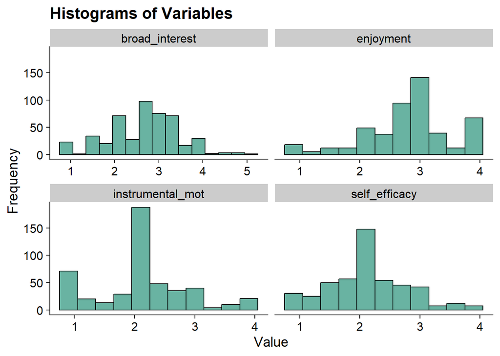

```r
data_long <- pisa %>%
    pivot_longer(broad_interest:self_efficacy, names_to = "variable")

ggplot(data_long, aes(x = value)) + geom_histogram(binwidth = 0.3, fill = "#69b3a2",
    color = "black") + facet_wrap(~variable, scales = "free_x") + labs(title = "Histograms of Variables",
    x = "Value", y = "Frequency") + theme_cowplot()
```

## Enumeration

### `tidyLPA`

Enumerate using `estimate_profiles()`:

- Estimate models with profiles $K = 1:6$
- Model has 4 continuous indicators
- Default variance-covariance specifications (model 1)
- Change `variances` and `covariances` to indicate the model you want to specify, in this example, we are estimating all six models.

```r
# Run LPA models
lpa_fit <- pisa %>%
    estimate_profiles(1:6, package = "MplusAutomation", ANALYSIS = "starts = 500 100;",
        OUTPUT = "sampstat residual tech11 tech14", variances = c("equal", "varying",
            "equal", "varying", "equal", "varying"), covariances = c("zero", "zero",
            "equal", "equal", "varying", "varying"), keepfiles = TRUE)

# Compare fit statistics
get_fit(lpa_fit)


# Move files to folder
files <- list.files(here(), pattern = "^model")
move_files(files, here("tidyLPA"), overwrite = TRUE)
```

CHECK EVERY SINGLE OUTPUT TO ENSURE MODELS CONVERGED AND MAKE NOTE OF MODELS THAT DID NOT!

…please :)

### `Mplus`

Alternative method to `estimate_profiles()`: Run enumeration using `mplusObject` method

You can change the model specification for LPA using the syntax provided in lecture.

#### Model 1

When estimating LPA in Mplus, the default variance/covariance specification is the most restricted model (Model 1). So we don’t have to specify anything here.

```r
lpa_k14  <- lapply(1:6, function(k) {
  lpa_enum  <- mplusObject(

    TITLE = glue("Profile {k}"),

    VARIABLE = glue(
    "usevar = broad_interest-self_efficacy;
     classes = c({k}); "),

  ANALYSIS =
   "estimator = mlr;
    type = mixture;
    starts = 500 100;",

  OUTPUT = "sampstat svalues residual tech11 tech14;",

  usevariables = colnames(pisa),
  rdata = pisa)

lpa_enum_fit <- mplusModeler(lpa_enum,
                dataout=glue(here("enum_lpa", "lpa_pisa")),
                modelout=glue(here("enum_lpa", "c{k}_lpa_m1.inp")) ,
                check=TRUE, run = TRUE, hashfilename = FALSE)
})
```

#### Model 2

Here, an addition loop adds the variance/covariance specifications for each profile-specific statement. For the profile-varying/diagonal specification, you must specify the variances to be freely estimated:

`broad_interest-self_efficacy;`

```r
lpa_m2_k14  <- lapply(1:6, function(k){

  # This MODEL section changes the model specification
  MODEL <- paste(sapply(1:k, function(i) {
    glue("
    %c#{i}%
    broad_interest-self_efficacy;      ! variances are freely estimated
    ")
  }), collapse = "\n")

  lpa_enum_m2  <- mplusObject(
    TITLE = glue("Profile {k} - Model 2"),

    VARIABLE = glue(
      "usevar = broad_interest-self_efficacy;
     classes = c({k});"),

    ANALYSIS =
      "estimator = mlr;
    type = mixture;
    starts = 500 100;",

    MODEL = MODEL,


    OUTPUT = "sampstat svalues residual tech11 tech14;",

    usevariables = colnames(pisa),
    rdata = pisa)

  lpa_m2_fit <- mplusModeler(lpa_enum_m2,
                             dataout = here("enum_lpa", "lpa_pisa"),
                             modelout = glue(here("enum_lpa","c{k}_lpa_m2.inp")),
                             check = TRUE, run = TRUE, hashfilename = FALSE)
})
```

For reference, here is the Mplus syntax for different specifications:

**Fixed covariance to zero (DEFAULT)**:

`broad_interest WITH enjoyment@0;`

**Free covariance**:

`broad_interest WITH enjoyment;`

**Equal covariances**:

`%c#1%`

`broad_interest WITH enjoyment (1);`

`%c#2%`

`broad_interest WITH enjoyment (1);`

**Equal variance (DEFAULT)**:

`%c#1%`

`broad_interest (1);`

`%c#2%`

`broad_interest (1);`

**Free variance**:

`mth_scor-bio_scor;`

You can also open the `tidyLPA` .inp files to see the specifications.

## Table of Fit

Evaluate each model specification separately using fit indices.

After examining the outputs (and increasing the random starts where necessary), there are a few models excluded from analysis:

Model 2:

- Profile 4
- Profile 5
- Profile 6

Model 3:

- Profile 5
- Profile 6

Model 4:

- Profile 4
- Profile 5
- Profile 6

Model 5:

- Profile 3
- Profile 4
- Profile 5
- Profile 6

Model 6:

- Profile 4
- Profile 5
- Profile 6

```r
source("enum_table")

# Read in model
output_pisa <- readModels(here("tidyLPA"), quiet = TRUE)

# Preview with numbered rows
enum_fit(output_pisa)
```

```
## # A tibble: 35 × 12
##      row Title             Parameters     LL   BIC  aBIC  CAIC   AWE BLRT_PValue
##    <int> <chr>                  <dbl>  <dbl> <dbl> <dbl> <dbl> <dbl>       <dbl>
##  1     1 Model 1 With 1 C…          8 -2089. 4227. 4201. 4235. 4300.          NA
##  2     2 Model 1 With 2 C…         13 -1997. 4074. 4032. 4087. 4193.           0
##  3     3 Model 1 With 3 C…         18 -1953. 4017. 3960. 4035. 4183.           0
##  4     4 Model 1 With 4 C…         23 -1889. 3921. 3848. 3944. 4133.           0
##  5     5 Model 1 With 5 C…         28 -1871. 3915. 3826. 3943. 4172.           0
##  6     6 Model 1 With 6 C…         33 -1858. 3921. 3816. 3954. 4224.           0
##  7     7 Model 2 With 1 C…          8 -2089. 4227. 4201. 4235. 4300.          NA
##  8     8 Model 2 With 2 C…         17 -1989. 4083. 4029. 4100. 4239.           0
##  9     9 Model 2 With 3 C…         26 -1878. 3917. 3834. 3943. 4156.           0
## 10    10 Model 2 With 4 C…         35 -1851. 3919. 3808. 3954. 4241.           0
## # ℹ 25 more rows
## # ℹ 3 more variables: T11_VLMR_PValue <dbl>, BF <dbl>, cmPk <dbl>
```

```r
select_models <-LatexSummaryTable(output_pisa,
                keepCols=c("Title", "Parameters", "LL", "BIC", "aBIC",
                           "BLRT_PValue", "T11_VLMR_PValue","Observations")) %>%
  slice( # Remove the models that we don't want to consider!!!! Because we looked at every single output, we know which models did not converge, thus we exclude them.
    # Model 2
    -10, -11, -12,
    # Model 3
    -17, -18,
    # Model 4
    -22, -23, -24,
    # Model 5
    -27, -28, -29, -30,
    # Model 6
    -34, -35, -36
  )


# Check to make sure that the rows of the models we don't want are removed
#View(select_models)

# Fit table
enum_table(select_models, 1:6, 7:9, 10:13, 14:16, 17:18, 19:21)
```

**Model Fit Summary Table**<sup>1</sup>

| Classes | Par | *LL* | BIC | aBIC | CAIC | AWE | BLRT | VLMR | BF | *cmPk* |
| --- | --- | --- | --- | --- | --- | --- | --- | --- | --- | --- |
| Model 1 |  |  |  |  |  |  |  |  |  |  |
| Model 1 With 1 Classes | 8 | −2,088.66 | 4,226.84 | 4,201.45 | 4,234.84 | 4,300.36 | – | – | 0.0 | <.001 |
| Model 1 With 2 Classes | 13 | −1,996.51 | 4,073.50 | 4,032.24 | 4,086.50 | 4,192.97 | <.001 | <.001 | 0.0 | <.001 |
| Model 1 With 3 Classes | 18 | −1,952.98 | 4,017.38 | 3,960.25 | 4,035.38 | 4,182.81 | <.001 | 0.009 | 0.0 | <.001 |
| Model 1 With 4 Classes | 23 | −1,889.43 | 3,921.23 | 3,848.23 | 3,944.23 | 4,132.61 | <.001 | <.001 | 0.0 | 0.043 |
| Model 1 With 5 Classes | 28 | −1,870.91 | 3,915.16 | 3,826.28 | 3,943.15 | 4,172.48 | <.001 | 0.018 | 16.0 | 0.901 |
| Model 1 With 6 Classes | 33 | −1,858.21 | 3,920.71 | 3,815.97 | 3,953.71 | 4,223.99 | <.001 | 0.025 | – | 0.056 |
| Model 2 |  |  |  |  |  |  |  |  |  |  |
| Model 2 With 1 Classes | 8 | −2,088.66 | 4,226.84 | 4,201.45 | 4,234.84 | 4,300.36 | – | – | 0.0 | <.001 |
| Model 2 With 2 Classes | 17 | −1,988.99 | 4,083.22 | 4,029.26 | 4,100.22 | 4,239.45 | <.001 | <.001 | 0.0 | <.001 |
| Model 2 With 3 Classes | 26 | −1,877.96 | 3,916.88 | 3,834.35 | 3,942.88 | 4,155.83 | <.001 | <.001 | – | 1.000 |
| Model 3 |  |  |  |  |  |  |  |  |  |  |
| Model 3 With 1 Classes | 14 | −1,968.35 | 4,023.36 | 3,978.93 | 4,037.36 | 4,152.02 | – | – | 0.1 | <.001 |
| Model 3 With 2 Classes | 19 | −1,950.11 | 4,017.84 | 3,957.53 | 4,036.84 | 4,192.45 | <.001 | 0.002 | 0.0 | <.001 |
| Model 3 With 3 Classes | 24 | −1,930.36 | 4,009.29 | 3,933.12 | 4,033.29 | 4,229.86 | <.001 | 0.171 | 0.0 | <.001 |
| Model 3 With 4 Classes | 29 | −1,840.85 | 3,861.23 | 3,769.18 | 3,890.23 | 4,127.75 | <.001 | <.001 | – | 1.000 |
| Model 4 |  |  |  |  |  |  |  |  |  |  |
| Model 4 With 1 Classes | 14 | −1,968.35 | 4,023.36 | 3,978.93 | 4,037.36 | 4,152.02 | – | – | 0.0 | <.001 |
| Model 4 With 2 Classes | 23 | −1,930.96 | 4,004.30 | 3,931.30 | 4,027.30 | 4,215.67 | <.001 | <.001 | 0.0 | <.001 |
| Model 4 With 3 Classes | 32 | −1,859.47 | 3,917.02 | 3,815.45 | 3,949.02 | 4,211.11 | <.001 | 0.033 | – | 1.000 |
| Model 5 |  |  |  |  |  |  |  |  |  |  |
| Model 5 With 1 Classes | 14 | −1,968.35 | 4,023.36 | 3,978.93 | 4,037.36 | 4,152.02 | – | – | 0.0 | <.001 |
| Model 5 With 2 Classes | 25 | −1,927.10 | 4,008.95 | 3,929.60 | 4,033.95 | 4,238.71 | <.001 | <.001 | – | 0.999 |
| Model 6 |  |  |  |  |  |  |  |  |  |  |
| Model 6 With 1 Classes | 14 | −1,968.35 | 4,023.36 | 3,978.93 | 4,037.36 | 4,152.02 | – | – | 0.0 | 0.044 |
| Model 6 With 2 Classes | 29 | −1,918.84 | 4,017.19 | 3,925.15 | 4,046.19 | 4,283.71 | <.001 | 0.004 | >100 | 0.956 |
| Model 6 With 3 Classes | 44 | −1,885.73 | 4,043.84 | 3,904.18 | 4,087.83 | 4,448.21 | <.001 | 0.009 | – | <.001 |

<sup>1</sup> *Note.* Par = Parameters; *LL* = model log likelihood; BIC = Bayesian information criterion; aBIC = sample size adjusted BIC; CAIC = consistent Akaike information criterion; AWE = approximate weight of evidence criterion; BLRT = bootstrapped likelihood ratio test p-value; cmPk = approximate correct model probability.

## Information Criteria Plot

Look for “elbow” to help with profile selection

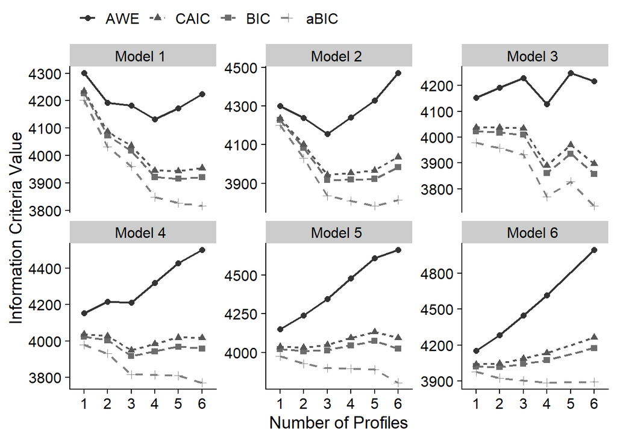

```r
source("ic_plot")
ic_plot(output_pisa)
```

Based on fit indices, I am choosing the following candidate models:

1. Model 1: 5 Profile
2. Model 2: 3 Profile
3. Model 3: 4 Profile
4. Model 4: 3 Profile
5. Model 5: 2 Profile
6. Model 6: 2 Profile

## Compare models

### Correct Model Probability (cmpK) recalculation

Take the candidate models and recalculate the approximate correct model probabilities (Masyn, 2013)

```r
# CmpK recalculation:
enum_fit1 <- select_models

stage2_cmpk <- enum_fit1 %>%
  slice(5, 9, 13, 16, 18, 20) %>% # Change this to select the rows of the candidate models
  mutate(CAIC = -2 * LL + Parameters * (log(Observations) + 1)) %>%
  mutate(AWE = -2 * LL + 2 * Parameters * (log(Observations) + 1.5)) %>%
  mutate(SIC = -.5 * BIC,
         expSIC = exp(SIC - max(SIC)),
         cmPk = expSIC / sum(expSIC),
         BF = exp(SIC - lead(SIC))) %>%
  select(Title, Parameters, BIC, aBIC, CAIC, AWE, cmPk, BF) %>%
  mutate(Title = str_to_title(Title))


# Format Fit Table
stage2_cmpk %>%
  gt() %>%
  tab_options(column_labels.font.weight = "bold") %>%
  fmt_number(
    7,
    decimals = 2,
    drop_trailing_zeros = TRUE,
    suffixing = TRUE
  ) %>%
  fmt_number(c(3:6),
             decimals = 2) %>%
    fmt_number(8,decimals = 2,
             drop_trailing_zeros=TRUE,
             suffixing = TRUE) %>%
  fmt(8, fns = function(x)
    ifelse(x>100, ">100",
           scales::number(x, accuracy = .1))) %>%
  tab_style(
    style = list(
      cell_text(weight = "bold")
      ),
    locations = list(cells_body(
     columns = BIC,
     row = BIC == min(BIC[1:nrow(stage2_cmpk)])
    ),
    cells_body(
     columns = aBIC,
     row = aBIC == min(aBIC[1:nrow(stage2_cmpk)])
    ),
    cells_body(
     columns = CAIC,
     row = CAIC == min(CAIC[1:nrow(stage2_cmpk)])
    ),
    cells_body(
     columns = AWE,
     row = AWE == min(AWE[1:nrow(stage2_cmpk)])
    ),
    cells_body(
     columns = cmPk,
     row =  cmPk == max(cmPk[1:nrow(stage2_cmpk)])
     ),
    cells_body(
     columns = BF,
     row =  BF > 10)
  )
)
```

| Title | Parameters | BIC | aBIC | CAIC | AWE | cmPk | BF |
| --- | --- | --- | --- | --- | --- | --- | --- |
| Model 1 With 5 Classes | 28 | 3,915.16 | 3,826.28 | 3,943.15 | 4,172.48 | 0 | 2.4 |
| Model 2 With 3 Classes | 26 | 3,916.88 | 3,834.35 | 3,942.88 | 4,155.83 | 0 | 0.0 |
| Model 3 With 4 Classes | 29 | 3,861.23 | 3,769.18 | 3,890.23 | 4,127.75 | 1 | >100 |
| Model 4 With 3 Classes | 32 | 3,917.02 | 3,815.45 | 3,949.02 | 4,211.11 | 0 | >100 |
| Model 5 With 2 Classes | 25 | 4,008.95 | 3,929.60 | 4,033.95 | 4,238.71 | 0 | 61.7 |
| Model 6 With 2 Classes | 29 | 4,017.19 | 3,925.15 | 4,046.19 | 4,283.71 | 0 | NA |

### Compare loglikelihood

You can also compare models using nested model testing directly with MplusAutomation. Note that you can only compare across models but the profiles must stay the same.

```r
# MplusAutomation Method using `compareModels`

compareModels(output_pisa[["model_2_class_3.out"]], output_pisa[["model_4_class_3.out"]],
    diffTest = TRUE)
```

```
##
## ==============
##
## Mplus model comparison
## ----------------------
##
## ------
## Model 1:  C:/Users/dnajiarch/Box/TA - ED 201/Labs/ucsb-mixture-lab6/tidyLPA/model_2_class_3.out
## Model 2:  C:/Users/dnajiarch/Box/TA - ED 201/Labs/ucsb-mixture-lab6/tidyLPA/model_4_class_3.out
## ------
##
## Model Summary Comparison
## ------------------------
##
##              m1                     m2
## Title        model 2 with 3 classes model 4 with 3 classes
## Observations 488                    488
## Estimator    MLR                    MLR
## Parameters   26                     32
## LL           -1877.965              -1859.466
## AIC          3807.929               3782.932
## BIC          3916.877               3917.022
##
##   MLR Chi-Square Difference Test for Nested Models Based on Loglikelihood
##   -----------------------------------------------------------------------
##
##   Difference Test Scaling Correction:  1.177167
##   Chi-square difference:  31.4297
##   Diff degrees of freedom:  6
##   P-value:  0
##
##   Note: The chi-square difference test assumes that these models are nested.
##   It is up to you to verify this assumption.
##
##   MLR Chi-Square Difference test for nested models
##   --------------------------------------------
##
##   Difference Test Scaling Correction:
##   Chi-square difference:
##   Diff degrees of freedom:
```

[output cut: 162 more lines]

```
##
##
##   Parameters unique to model 1: 0
##   -----------------------------
##
##   None
##
##
##   Parameters unique to model 2: 0
##   -----------------------------
##
##  None
##
##
## ==============
```

Here, Model 1 (restricted, fewer parameters) is nested in Model 2. The chi-square difference test, assuming nested models, shows a significant improvement in fit for Model 2 over Model 1, despite the added parameters.

### Plot comparison

We can also plot the comparisons and look at the error bars.

NOTE: The `plotMixtures()` function is used for plotting LPA models only (i.e., means & variances)

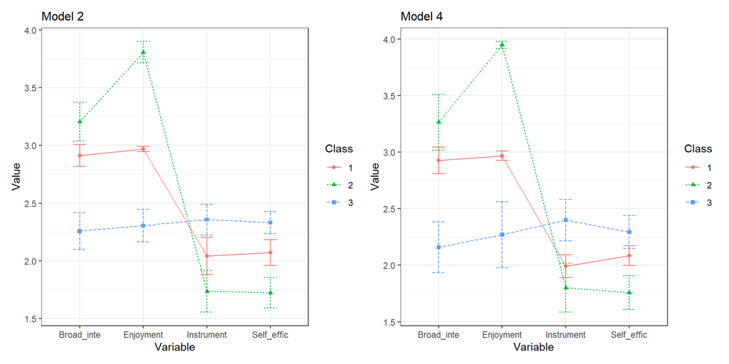

```r
a <- plotMixtures(output_pisa$model_2_class_3.out, ci = 0.95, bw = FALSE)

b <- plotMixtures(output_pisa$model_4_class_3.out, ci = 0.95, bw = FALSE)

a + labs(title = "Model 2") + theme(plot.title = element_text(size = 12)) + b + labs(title = "Model 4") +
    theme(plot.title = element_text(size = 12))
```

## Visualization

### Latent Profile Plot

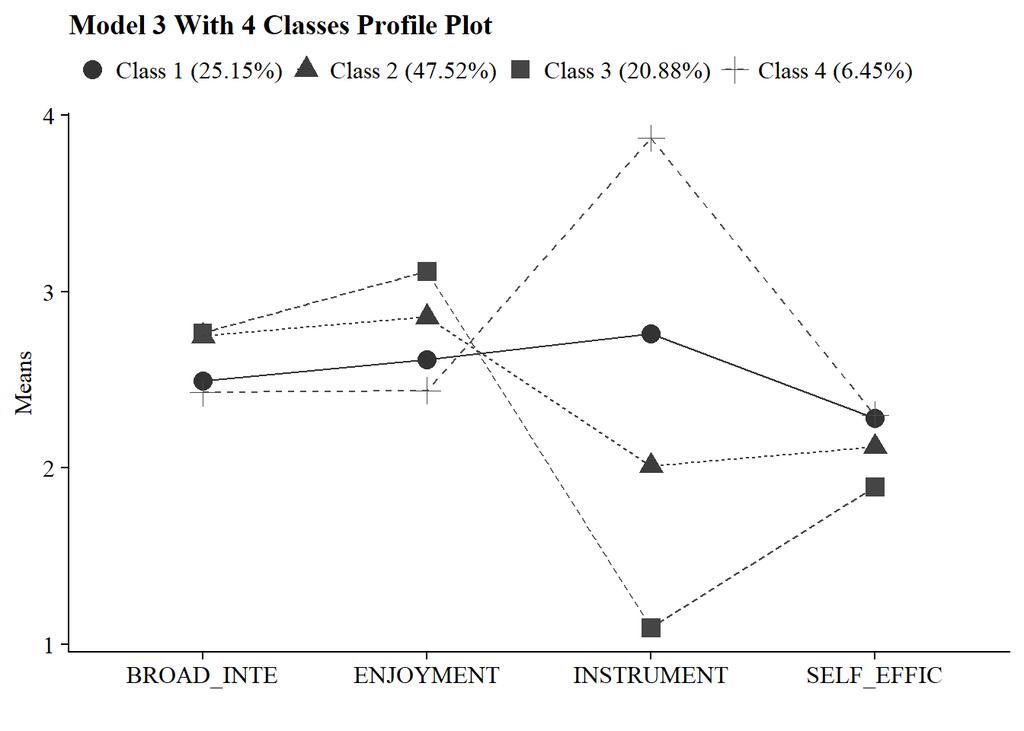

```r
source("plot_lpa.txt")

plot_lpa(model_name = output_pisa$model_3_class_4.out)
```

Save figure

```r
ggsave(here("figures", "model3_profile4.png"), dpi = "retina", bg = "white", height = 5,
    width = 8, units = "in")
```

### Plots Means and Variances

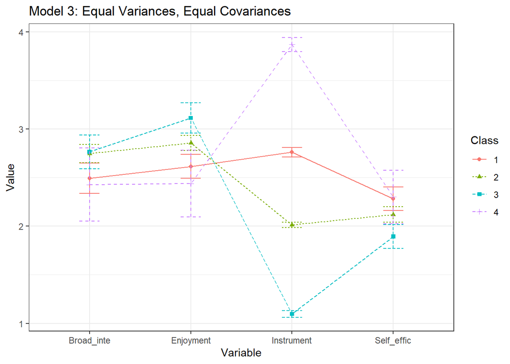

```r
plotMixtures(output_pisa$model_3_class_4.out, ci = 0.95, bw = FALSE) + labs(title = "Model 3: Equal Variances, Equal Covariances")
```

## Model Evaluation

### Classifications Diagnostics Table

Use Mplus to calculate k-profile confidence intervals (Note: Change the syntax to make your chosen *k*-profile model):

```r
classification  <- mplusObject(

  TITLE = "LPA - Calculated k-Class 95% CI",

  VARIABLE =
  "usevar =  broad_interest-self_efficacy;
   classes = c1(4);",

  ANALYSIS =
   "estimator = ml;
    type = mixture;
    starts = 0;
    processors = 10;
    optseed = 468036; ! This seed is taken from chosen model output
    bootstrap = 1000;",

  MODEL =
    "
    ! This is copied and pasted from the chosen model input
  %c1#1%
  broad_interest (vbroad_interest);
  enjoyment (venjoyment);
  instrumental_mot (vinstrumental_mot);
  self_efficacy (vself_efficacy);

  broad_interest WITH enjoyment (broad_interestWenjoyment);
  broad_interest WITH instrumental_mot (broad_interestWinstrumental_mot);
  broad_interest WITH self_efficacy (broad_interestWself_efficacy);
  enjoyment WITH instrumental_mot (enjoymentWinstrumental_mot);
  enjoyment WITH self_efficacy (enjoymentWself_efficacy);
  instrumental_mot WITH self_efficacy (instrumental_motWself_efficacy);

  %c1#2%
  broad_interest (vbroad_interest);
  enjoyment (venjoyment);
  instrumental_mot (vinstrumental_mot);
  self_efficacy (vself_efficacy);

  broad_interest WITH enjoyment (broad_interestWenjoyment);
  broad_interest WITH instrumental_mot (broad_interestWinstrumental_mot);
  broad_interest WITH self_efficacy (broad_interestWself_efficacy);
  enjoyment WITH instrumental_mot (enjoymentWinstrumental_mot);
  enjoyment WITH self_efficacy (enjoymentWself_efficacy);
  instrumental_mot WITH self_efficacy (instrumental_motWself_efficacy);

  %c1#3%
  broad_interest (vbroad_interest);
  enjoyment (venjoyment);
  instrumental_mot (vinstrumental_mot);
  self_efficacy (vself_efficacy);

  broad_interest WITH enjoyment (broad_interestWenjoyment);
  broad_interest WITH instrumental_mot (broad_interestWinstrumental_mot);
  broad_interest WITH self_efficacy (broad_interestWself_efficacy);
  enjoyment WITH instrumental_mot (enjoymentWinstrumental_mot);
  enjoyment WITH self_efficacy (enjoymentWself_efficacy);
  instrumental_mot WITH self_efficacy (instrumental_motWself_efficacy);

  %c1#4%
  broad_interest (vbroad_interest);
  enjoyment (venjoyment);
  instrumental_mot (vinstrumental_mot);
  self_efficacy (vself_efficacy);

  broad_interest WITH enjoyment (broad_interestWenjoyment);
  broad_interest WITH instrumental_mot (broad_interestWinstrumental_mot);
  broad_interest WITH self_efficacy (broad_interestWself_efficacy);
  enjoyment WITH instrumental_mot (enjoymentWinstrumental_mot);
  enjoyment WITH self_efficacy (enjoymentWself_efficacy);
  instrumental_mot WITH self_efficacy (instrumental_motWself_efficacy);


  !CHANGE THIS SECTION TO YOUR CHOSEN k-CLASS MODEL

  %OVERALL%
  [C1#1](c1);
  [C1#2](c2);
  [C1#3](c3);

  Model Constraint:
  New(p1 p2 p3 p4);

  p1 = exp(c1)/(1+exp(c1)+exp(c2)+exp(c3));
  p2 = exp(c2)/(1+exp(c1)+exp(c2)+exp(c3));
  p3 = exp(c3)/(1+exp(c1)+exp(c2)+exp(c3));
  p4 = 1/(1+exp(c1)+exp(c2)+exp(c3));",


  OUTPUT = "cinterval(bcbootstrap)",

  usevariables = colnames(pisa),
  rdata = pisa)

classification_fit <- mplusModeler(classification,
                dataout=here("mplus", "class.dat"),
                modelout=here("mplus", "class.inp") ,
                check=TRUE, run = TRUE, hashfilename = FALSE)
```

Create table

```r
source("diagnostics_table")

class_output <- readModels(here("mplus", "class.out"))

diagnostics_table(class_output)
```

Model Classification Diagnostics

| *k*-Class | *k*-Class Proportions | 95% CI | *mcaPk* | *AvePPk* | *OCCk* |
| --- | --- | --- | --- | --- | --- |
| Class 1 | 0.251 | [0.212, 0.294] | 0.258 | 0.946 | 52.276 |
| Class 2 | 0.475 | [0.428, 0.521] | 0.471 | 0.971 | 37.007 |
| Class 3 | 0.209 | [0.173, 0.244] | 0.207 | 0.983 | 218.844 |
| Class 4 | 0.064 | [0.046, 0.087] | 0.064 | 0.996 | 3641.625 |

### Profile Homogeneity

Profile homogeneity is the model-estimated within-profile variances for each indicator m across the k-profiles and comparing them to the total overall sample variance:

$$\frac{\theta_{mk}}{\theta_{m}}$$

```r
# Change this to look at your chosen LPA model

chosen_model <- output_pisa$model_3_class_4.out


# Extract overall and profile-specifc variances
overall_variances <- data.frame(chosen_model$sampstat$univariate.sample.statistics) %>%
    select(Variance) %>%
    rownames_to_column(var = "item") %>%
    clean_names() %>%
    mutate(item = str_sub(item, 1, 8))

profile_variances <- data.frame(chosen_model$parameters$unstandardized) %>%
    filter(paramHeader == "Variances") %>%
    select(param, est, LatentClass) %>%
    rename(item = param, variance = est, k = LatentClass) %>%
    mutate(k = paste0("Profile ", k)) %>%
    mutate(item = str_sub(item, 1, 8))


# Evaluate the ratio
homogeneity <- profile_variances %>%
    left_join(overall_variances, by = "item") %>%
    mutate(homogeneity_ratio = round((variance.x/variance.y), 2))

# Create a gt table
homogeneity %>%
    select(homogeneity_ratio, k, item) %>%
    pivot_wider(names_from = k, values_from = homogeneity_ratio) %>%
    gt() %>%
    cols_label(item = "Item") %>%
    fmt_number(columns = everything(), decimals = 3) %>%
    tab_header(title = "Profile Homogeneity Table") %>%
    tab_style(style = cell_text(weight = "bold"), locations = cells_column_labels())
```

Profile Homogeneity Table

| Item | Profile 1 | Profile 2 | Profile 3 | Profile 4 |
| --- | --- | --- | --- | --- |
| BROAD_IN | 0.970 | 0.970 | 0.970 | 0.970 |
| ENJOYMEN | 0.930 | 0.930 | 0.930 | 0.930 |
| INSTRUME | 0.060 | 0.060 | 0.060 | 0.060 |
| SELF_EFF | 0.950 | 0.950 | 0.950 | 0.950 |

### Profile Separation

You can evaluate the degree of profile separation is by assessing the actual distance between the profile-specific means. To quantify profile separation between Profile j and Profile k with respect to a particular item m, compute a standard mean difference:

$$\hat{d}_{mjk}=
\frac{{\hat{\alpha_{mj}}-\hat{\alpha_{mk}}}}{\sigma_{mjk}}$$
Pooled variance:

$$\hat{\sigma}_{mj k} =
\sqrt{\frac{(\hat{\pi}_j)(n)(\hat{\theta}_{mj}) +
(\hat{\pi}_k)(n)(\hat{\theta}_{mk})}{(\hat{\pi}_j + \hat{\pi}_k)
n}}$$

```r
# Change this to look at your chosen LPA model
chosen_model <- output_pisa$model_3_class_4.out


# Profile-specific means
profile_means <- data.frame(chosen_model$parameters$unstandardized) %>%
    filter(paramHeader == "Means") %>%
    filter(!str_detect(param, "#")) %>%
    select(param, est, LatentClass) %>%
    rename(item = param, means = est, k = LatentClass) %>%
    mutate(k = paste0("Profile ", k)) %>%
    mutate(item = str_sub(item, 1, 8))

# Relative profile sizes
profile_sizes <- data.frame(chosen_model$class_counts$modelEstimated) %>%
    rename(size = proportion, k = class) %>%
    mutate(k = paste0("Profile ", k)) %>%
    select(-count)

# Sample size
n <- chosen_model$summaries$Observations

# Profile-specific variance
profile_variances <- data.frame(chosen_model$parameters$unstandardized) %>%
    filter(paramHeader == "Variances") %>%
    select(param, est, LatentClass) %>%
    rename(item = param, variance = est, k = LatentClass) %>%
    mutate(k = paste0("Profile ", k)) %>%
    mutate(item = str_sub(item, 1, 8))

# Combine profile variances with profile sizes
variance_with_sizes <- profile_variances %>%
    left_join(profile_sizes, by = "k")

# Create the combinations
profile_combinations <- data.frame(comboGrid(k1 = unique(profile_sizes$k), k2 = unique(profile_sizes$k))) %>%
    filter(k1 != k2) %>%
    arrange(k1, k2)

# Calculate pooled variance for each item across the profiles
combined_results <- profile_combinations %>%
    rowwise() %>%
    do({
        pair <- .
        k1 <- pair$k1
        k2 <- pair$k2

        # Filter for the two profiles (variance)
        data_k1_var <- variance_with_sizes %>%
            filter(k == k1)
        data_k2_var <- variance_with_sizes %>%
            filter(k == k2)

        # Filter for the two profiles (means)
        data_k1_mean <- profile_means %>%
            filter(k == k1)
        data_k2_mean <- profile_means %>%
            filter(k == k2)

        # Combine variance data for the two profiles
        variance_data <- data_k1_var %>%
            inner_join(data_k2_var, by = "item", suffix = c("_k1", "_k2")) %>%
            mutate(pooled_variance = sqrt(((size_k1 * n * variance_k1) + (size_k2 *
                n * variance_k2))/((size_k1 + size_k2) * n)), comparison = paste(k1,
                "vs", k2)) %>%
            select(item, pooled_variance, comparison)

        # Combine mean data for the two profilees
        mean_data <- data_k1_mean %>%
            inner_join(data_k2_mean, by = "item", suffix = c("_k1", "_k2")) %>%
            mutate(mean_diff = means_k1 - means_k2, comparison = paste(k1, "vs",
                k2)) %>%
            select(item, mean_diff, comparison)

        # Combine both variance and mean differences data
        combined_data <- variance_data %>%
            left_join(mean_data, by = c("item", "comparison")) %>%
            mutate(mean_diff_by_pooled_variance = mean_diff/pooled_variance)

        combined_data
    }) %>%
    bind_rows()

# Create a gt table
combined_results %>%
    select(mean_diff_by_pooled_variance, comparison, item) %>%
    pivot_wider(names_from = comparison, values_from = mean_diff_by_pooled_variance) %>%
    gt() %>%
    cols_label(item = "Item") %>%
    fmt_number(columns = everything(), decimals = 3) %>%
    tab_header(title = "Profile Separation Table") %>%
    tab_style(style = cell_text(weight = "bold"), locations = cells_column_labels())
```

Profile Separation Table

| Item | Profile 1 vs Profile 2 | Profile 1 vs Profile 3 | Profile 1 vs Profile 4 | Profile 2 vs Profile 3 | Profile 2 vs Profile 4 | Profile 3 vs Profile 4 |
| --- | --- | --- | --- | --- | --- | --- |
| BROAD_IN | −0.334 | −0.357 | 0.084 | −0.024 | 0.418 | 0.442 |
| ENJOYMEN | −0.346 | −0.722 | 0.255 | −0.375 | 0.602 | 0.977 |
| INSTRUME | 4.004 | 8.900 | −5.923 | 4.896 | −9.926 | −14.822 |
| SELF_EFF | 0.261 | 0.621 | −0.027 | 0.360 | −0.288 | −0.648 |

## References

Hallquist, M. N., & Wiley, J. F. (2018). MplusAutomation: An R Package for Facilitating Large-Scale Latent Variable Analyses in Mplus. Structural equation modeling: a multidisciplinary journal, 25(4), 621-638.

Miller, J. D., Hoffer, T., Suchner, R., Brown, K., & Nelson, C. (1992). LSAY codebook. Northern Illinois University.

Muthén, B. O., Muthén, L. K., & Asparouhov, T. (2017). Regression and mediation analysis using Mplus. Los Angeles, CA: Muthén & Muthén.

Muthén, L.K. and Muthén, B.O. (1998-2017). Mplus User’s Guide. Eighth Edition. Los Angeles, CA: Muthén & Muthén

Rosenberg, J. M., van Lissa, C. J., Beymer, P. N., Anderson, D. J., Schell, M. J. & Schmidt, J. A. (2019). tidyLPA: Easily carry out Latent Profile Analysis (LPA) using open-source or commercial software [R package]. https://data-edu.github.io/tidyLPA/

R Core Team (2017). R: A language and environment for statistical computing. R Foundation for Statistical Computing, Vienna, Austria. URL http://www.R-project.org/

Wickham et al., (2019). Welcome to the tidyverse. Journal of Open Source Software, 4(43), 1686, https://doi.org/10.21105/joss.01686